# Equations of Straight Line Graphs - Part 2

06 April, 2022

### KS3: Plotting and finding the equations of straight line graphs (y=mx+c) - Part 2

### Lesson objectives

Plotting and finding the equations of straight line graphs y=mx+c

### Packages used in this lesson:

- `tidyverse`

### Success criteria

- Plot a straight line graph y = mx+c
- Plot straight line graphs y = mx+c with different intercepts
- Plot a straight line graph y = mx+c with a negative gradient
- Find the equations of straight line graphs

### Keywords

- slope
- gradient
- intercept
- x-axis
- y-axis

#### Worked Example 1

This is a worked example for you to follow.

We will show you how to plot the line graph for y=2x + 5.

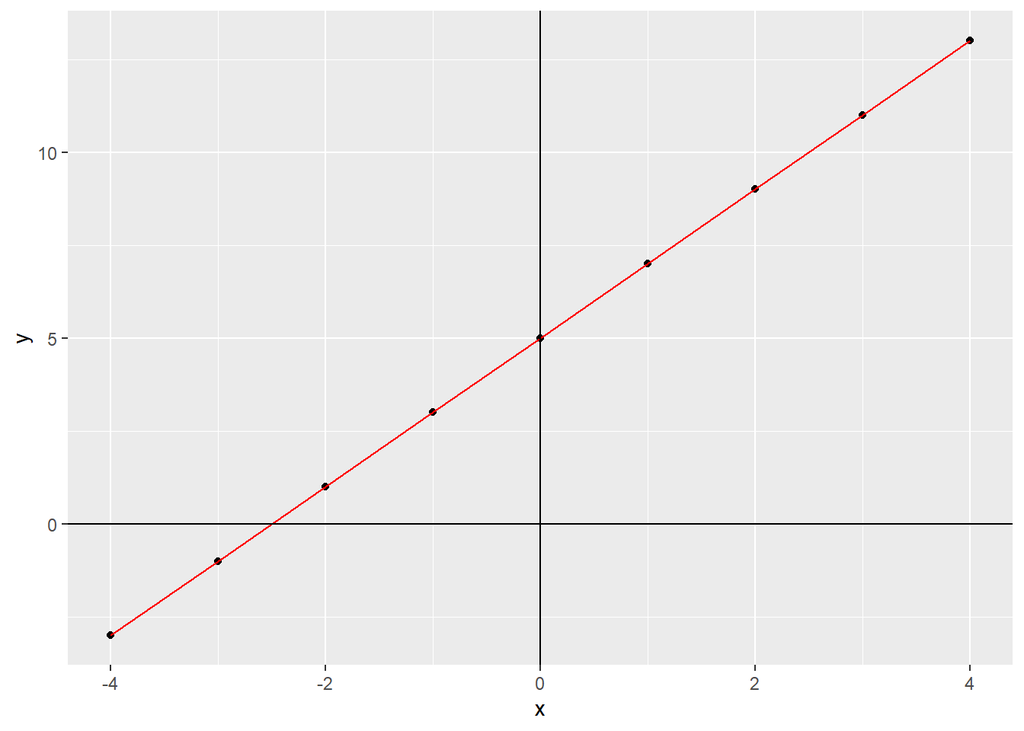

```r
x <- seq(from=-4, to=4, by=1) # sequence the x-axis from -4 to 4
y <- 2*x+5
mydata <- tibble (x,y)
ggplot(mydata) +
  aes(x,y) +
  geom_point () +
  geom_line (col='red')+
  geom_vline (xintercept = 0, col='black')+
  geom_hline (yintercept = 0, col='black')
```

#### Worked Example 2

We will now see what happens when you change the intercept c to a negative value.

1. y=3x+5
2. y=3x-5

Run the code in chunk2 by clicking on the little arrow on the right of the code chunk.

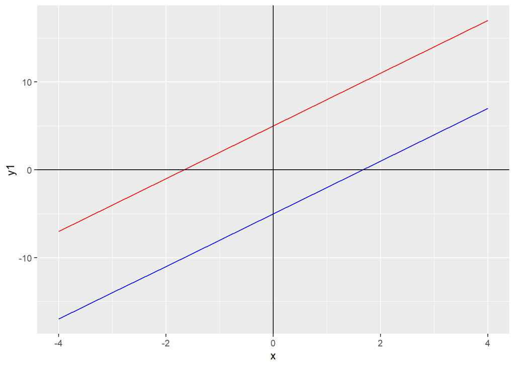

```r
x <- seq(-4, 4) # sequence from -4 to 4
y1 <- 3*x+5
y2 <- 3*x-5
mydata <- tibble (x,y1,y2,y)
ggplot(mydata) +
  geom_line (aes(x=x, y=y1), col='red')+
  geom_line (aes(x=x, y=y2), col='blue')+
  geom_vline (xintercept = 0, col='black')+
  geom_hline (yintercept = 0, col='black')
```

Question: What is the same and what is different about these lines?

Answer:

Knit your document and check the output.

#### Activity 1

Draw these lines on a graph. Use the R code from chunk2 to help you. Remember to update the code with these new lines.

1. y=x+10
2. y=x-10

Question: What is the same and what is different about these lines?

Answer:

#### Activity 2

Now we will investigate m (the gradient). Draw these lines on a graph. Use R code from chunk2 to help you.

Run the code and knit the document.

1. y=-2x+5
2. y= 2x+5

Question: What is the same and what is different about these lines?

Answer:

#### Activity 3 Answer the following questions

```
## Q1 In the equation y=mx+c, what happens when you change c?
```

```
## Q2 What happens when you change m?
```

Write your answers here  
Q1:

Q2:

#### Activity 4: Work out the equation from a line graph

Write down the equations of the following four lines on the graph below.

Knit the document to get a good view of the graph.

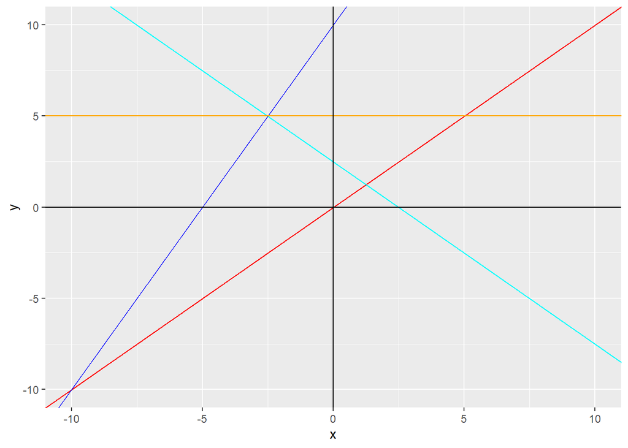

Write your answers here

Cyan line:

Red line:

Blue line:

Orange line: